# Spreadsheets

```r
library("tidyverse")
library("knitr")
library("readxl")
library("here")
library("janitor")
```

# Sticker Wealth

**Set your path here:**

```r
stickers_path <- here("09_data-import/spreadsheets/PosidFazioCordes_StickerRich_Excel-Dataverse.xlsx")
```

We’re going to read in some messy data from an Excel file that accompanies a journal article about how children’s altruistic behavior is shaped by their “wealth” in terms of the number of stickers they have: [Being Sticker Rich: Numerical Context Influences Children’s Sharing Behavior](https://journals.plos.org/plosone/article?id=10.1371/journal.pone.0138928). The data are [archived in a data repository](https://dataverse.harvard.edu/dataset.xhtml?persistentId=doi:10.7910/DVN/LHAQ5W), but they can also be downloaded from the course website.

As a first attempt, let’s just read in the file using `read_excel()` with no other options provided.

```r
stickers <- read_excel(stickers_path)
```

Let’s look at that mess.

```r
stickers
```

```
## # A tibble: 402 x 18
##    `Subject Number`   Condition      `Number Sticker… `Number Envelopes` Gender
##    <chr>              <chr>          <chr>            <chr>              <chr>
##  1 [Included Sample … 1=12:1; 2=12:… 1=12; 2=30       1=1 recipient; 2=… 1=fema…
##  2 1                  1              1                1                  1
##  3 2                  1              1                1                  2
##  4 3                  1              1                1                  2
##  5 4                  1              1                1                  1
##  6 5                  1              1                1                  2
##  7 6                  1              1                1                  2
##  8 7                  2              1                2                  1
##  9 8                  2              1                2                  2
## 10 9                  3              2                1                  2
## # … with 392 more rows, and 13 more variables: Age_months <dbl>,
## #   Age_years <dbl>, Age_groups <chr>, Subject's Envelope <chr>,
## #   Left Envelope <chr>, Right Envelope <chr>,
## #   absolute number of stickers given (Conditions 1 or 3: Out of 12; Conditions 2 or 4: Out of 30) <chr>,
## #   Percent Given (Out of 100 percent) <chr>, Give or not <chr>,
## #   LargerEnvelope_abs <chr>, LargeEnvelope_percent <chr>,
## #   SmallerEnvelope_abs <chr>, SmallEnvelope_percent <chr>
```

```r
# Get row 2 only
slice(stickers, 2)

# Get rows 1 to 3
slice(stickers, 1:3)

# Get the last row only with the function n(), which is the number of rows in the table
slice(stickers, n())

# Get rows 2 to last row
slice(stickers, 2:n())

# Another way of writing the same thing is with negative indices (for rows to to remove)
slice(stickers, -1)
```

Another issue is that some of the column names have completely ridiculous names like `absolute number of stickers given (Conditions 1 or 3: Out of 12; Conditions 2 or 4: Out of 30)`.

```r
names(stickers)
```

```
##  [1] "Subject Number"
##  [2] "Condition"
##  [3] "Number Stickers"
##  [4] "Number Envelopes"
##  [5] "Gender"
##  [6] "Age_months"
##  [7] "Age_years"
##  [8] "Age_groups"
##  [9] "Subject's Envelope"
## [10] "Left Envelope"
## [11] "Right Envelope"
## [12] "absolute number of stickers given (Conditions 1 or 3: Out of 12; Conditions 2 or 4: Out of 30)"
## [13] "Percent Given (Out of 100 percent)"
## [14] "Give or not"
## [15] "LargerEnvelope_abs"
## [16] "LargeEnvelope_percent"
## [17] "SmallerEnvelope_abs"
## [18] "SmallEnvelope_percent"
```

If we enjoyed wasting time, we could fix that by manually renaming each column. Instead, let’s use the R package `janitor`, which provides a handy function `clean_names()` for making nice names using a variety of rules. By default, it makes names using [snake_case](https://en.wikipedia.org/wiki/Snake_case), but you can find all the other options in the [documentation](https://rdrr.io/cran/snakecase/man/to_any_case.html), including such delightful naming rules as “big_camel” (NamesLikeThis) and “screaming_snake” (NAMES_LIKE_THIS).

```r
clean_stickers <- clean_names(stickers)
names(clean_stickers)
```

```
##  [1] "subject_number"
##  [2] "condition"
##  [3] "number_stickers"
##  [4] "number_envelopes"
##  [5] "gender"
##  [6] "age_months"
##  [7] "age_years"
##  [8] "age_groups"
##  [9] "subjects_envelope"
## [10] "left_envelope"
## [11] "right_envelope"
## [12] "absolute_number_of_stickers_given_conditions_1_or_3_out_of_12_conditions_2_or_4_out_of_30"
## [13] "percent_given_out_of_100_percent"
## [14] "give_or_not"
## [15] "larger_envelope_abs"
## [16] "large_envelope_percent"
## [17] "smaller_envelope_abs"
## [18] "small_envelope_percent"
```

## Finished Product: Stickers

Read in the stickers data in one fell swoop using piped functions. Your chain should be 5 lines long:

1. Start with path to the data
2. Call read_excel
3. Slice out the bad row
4. Rename the long column
5. Clean the names using janitor

# Messy Archeological Artifacts

In this activity we’re going to import data from a messy spreadsheet of mass measurements on archeological artifacts including lithics, ceramics, and molluscs. I found the data in a public respository for an [Archeological Data Analysis Workshop](https://github.com/benmarwick/SAA_R_workshop_2017) by MAtthew Harris and Ben Marwick.

Go ahead and open the file `messy_ktc_data.xlsx`. Look upon the single worksheet with tables nested within tables and despair. This file violates practically every guideline in Broman and Woo’s [“Data organization in spreadsheets”](https://kbroman.org/dataorg/).

We have three goals here:

1. Read in the subtable labeled “Ceramic data” and put it in an object called `ceramic`.
2. Read in the subtable labeled “lithic data” and put it in an object called `lithic`.
3. Read in all the mollusc data organized into 17 (?!?!!) subtables and put it all together in an object called `mollusc`.

**Set your path here:**

```r
artifacts_path <- here("09_data-import/spreadsheets/messy_ktc_data.xlsx")
```

The first two are easy. Simply provide the cell range to the `read_excel()` function.

```
## Rows: 101
## Columns: 9
## $ Trench   <chr> "A", "A", "A", "A", "A", "A", "A", "A", "A", "A", "A", "A", "…
## $ Square   <chr> "SW1", "SW1", "SW1", "SW1", "SW1", "SW1", "SW1", "SW1", "SW1"…
## $ EU       <dbl> 1, 1, 1, 1, 1, 1, 1, 1, 1, 2, 2, 2, 2, 2, 2, 2, 2, 2, 2, 2, 2…
## $ Context  <chr> "1", "1", "1", "1", "1", "1", "1", "1", "1", "1", "1", "1", "…
## $ Unit     <dbl> 1, 1, 1, 1, 1, 1, 1, 1, 1, 2, 2, 2, 2, 2, 2, 2, 2, 2, 2, 2, 2…
## $ Counts   <dbl> 14, 1, 1, 1, 1, 1, 1, 1, 1, 1, 51, 1, 1, 1, 1, 1, 1, 1, 1, 1,…
## $ Mass     <dbl> 27.2, 5.8, 0.5, 0.0, 0.6, 0.6, 0.5, 1.0, 0.4, 5.1, 72.1, 3.5,…
## $ Recorder <chr> "CC", "CC", "CC", "CC", "CC", "CC", "CC", "CC", "CC", "HVV", …
## $ Date     <dttm> 2008-07-28, 2008-07-28, 2008-07-28, 2008-07-28, 2008-07-28, …
```

```
## Rows: 12
## Columns: 10
## $ Trench      <chr> "A", "A", "A", "A", "A", "A", "A", "A", "A", "A", "A", "A"
## $ Square      <chr> "SW1", "SW2", "SW5", "SW6", "SW6", "SW9", "SW11", "SW14", …
## $ EU          <dbl> 1, 2, 5, 6, 6, 9, 11, 14, 15, 18, 19, 20
## $ Unit        <dbl> 1, 2, 9, 12, 13, 16, 17, 19, 19, 24, 27, 27
## $ Lithic_Type <chr> "Flake", "Flake", "Flake", "Flake", "Flake", "Flake", "Fla…
## $ Counts      <dbl> 1, 1, 20, 3, 8, 2, 2, 1, 2, 4, 2, 2
## $ Mass        <dbl> 0.3, 18.4, 73.6, 6.1, 13.3, 2.7, 6.3, 0.9, 2.6, 41.0, 9.7,…
## $ Recorder    <chr> "CC", "HVV", "CC", "HVV", "CC", "HVV", "HVV", "HVV", "HVV"…
## $ Date        <dttm> 2008-07-28, 2008-07-28, 2008-07-28, 2008-07-28, 2008-07-28…
## $ Context     <chr> "1", "1", "4", "5", "5", "6", "7U", "8", "8", "7L", "7L", …
```

Mollusc is a bit more complicated, but still not so bad. If we simply provide the cell range:

```
## Rows: 199
## Columns: 13
## $ Trench               <chr> "A", "Trench", "A", "A", "A", "A", "A", "A", "A",…
## $ Unit                 <chr> "SW2", "Unit", "SW4", "SW4", "SW4", "SW4", "SW4",…
## $ Context              <chr> "2", "Context", "5", "5", "5", "5", "5", "5", "5"…
## $ Taxon                <chr> "Unknown", "Taxon", "F. Viviparidae", "F. Arcidae…
## $ Element              <chr> "Bivalve", "Element", "Gastropod", "Bivalve", "Ga…
## $ `Mass (g)`           <chr> "0.9", "Mass (g)", "1.3", "0.8", "1.5", "16.7", "…
## $ Count                <chr> "1", "Count", "1", "1", "1", "8", "8", "12", "4",…
## $ `Max L/W mm`         <chr> "NA", "Max L/W mm", "NA", "NA", "NA", "NA", "NA",…
## $ `Burnt/Not Burnt`    <chr> "N", "Burnt/Not Burnt", "N", "N", "N", "N", "N", …
## $ `Cutmark/No Cutmark` <chr> "N", "Cutmark/No Cutmark", "N", "N", "N", "N", "N…
## $ Recorder             <chr> "HVV", "Recorder", "HVV", "HVV", "HVV", "HVV", "H…
## $ NOTES                <chr> NA, "NOTES", NA, NA, NA, NA, NA, NA, NA, NA, "NOT…
## $ Date                 <chr> "41099", "Date", "41099", "41099", "41099", "4109…
```

Everything is treated as a text column because the column headings for each subtable are intermixed with the data values. To fix this, write a sequence of commands in which you:

1. Start with path to the data.
2. Call read_excel() on the appropriate range and use the `col_types` argument to specify the column type for each column.
3. Filter out all the rows that correspond with column headings.
4. Clean the names using `clean_names()` from the `janitor` package.

```
## Rows: 183
## Columns: 13
## $ trench             <chr> "A", "A", "A", "A", "A", "A", "A", "A", "A", "A", "…
## $ unit               <chr> "SW2", "SW4", "SW4", "SW4", "SW4", "SW4", "SW4", "S…
## $ context            <chr> "2", "5", "5", "5", "5", "5", "5", "5", "5", "9", "…
## $ taxon              <chr> "Unknown", "F. Viviparidae", "F. Arcidae Anadara sp…
## $ element            <chr> "Bivalve", "Gastropod", "Bivalve", "Gastropod", "Ga…
## $ mass_g             <dbl> 0.9, 1.3, 0.8, 1.5, 16.7, 3.2, 1.4, 3.7, 1.0, 1.3, …
## $ count              <dbl> 1, 1, 1, 1, 8, 8, 12, 4, 2, 1, 1, 1, 1, 2, 1, 3, 4,…
## $ max_l_w_mm         <dbl> NA, NA, NA, NA, NA, NA, NA, NA, NA, 21.16, 25.06, 2…
## $ burnt_not_burnt    <chr> "N", "N", "N", "N", "N", "N", "N", "N", "N", "N", "…
## $ cutmark_no_cutmark <chr> "N", "N", "N", "N", "N", "N", "N", "N", "N", "N", "…
## $ recorder           <chr> "HVV", "HVV", "HVV", "HVV", "HVV", "HVV", "HVV", "H…
## $ notes              <chr> NA, NA, NA, NA, NA, NA, NA, NA, NA, "F-100-0168 B-1…
## $ date               <dttm> 2012-07-09, 2012-07-09, 2012-07-09, 2012-07-09, 20…
```

Finally, let’s make a histogram to visualize the mass distributions of bivalves and gastropods from our sample.

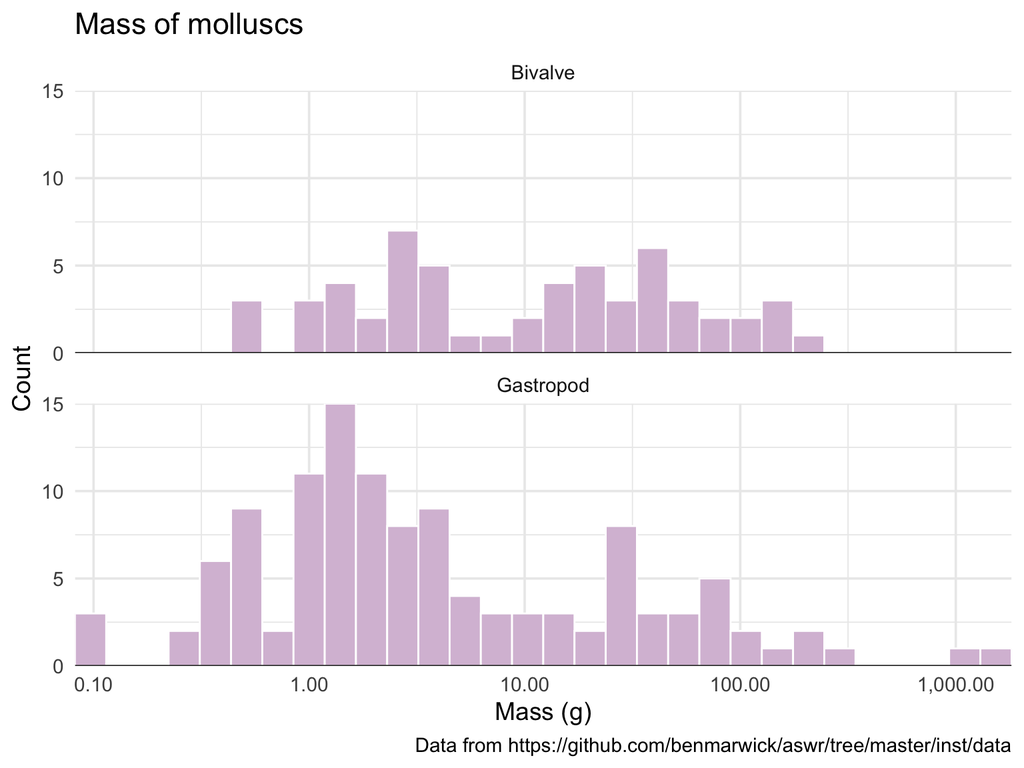

```r
ggplot(filter(mollusc, element %in% c("Bivalve", "Gastropod")),
       aes(x = mass_g + 0.1)) +            # Add a little bit to mass to avoid log(0) problem
  geom_histogram(color = "white",
                 fill = "thistle") +
  geom_hline(yintercept = 0) +             # Make nice black baseline at zero
  scale_x_log10(labels = scales::comma) +  # Log-transform x-axis, and use comma lables
  facet_wrap(~element, ncol = 1) +         # Arrange facets in single column
  coord_cartesian(expand = FALSE) +        # Don't add extra space around extremes of the plot
  theme_minimal(14) +
  labs(x = "Mass (g)", y = "Count",
       title = "Mass of molluscs",
       caption = "Data from https://github.com/benmarwick/aswr/tree/master/inst/data")
```